# Google Data Analytics Capstone Project -Bellabeat

Sarah Oluwatobi Nkereuwem

2023-07-26

[figure not shown]

## **INTRODUCTION**

This is one of the Google professional data analytics capstone project that focuses on high-tech health products manufactured by Bellabeat for women.  
This helps women to track their overall health and wellness and also get a better understanding of how their body works.  
Bellabeat has 5 focus products: Belabeat app, leaf, time, spring and membership. This is a small company with the potential to become a major player in the global smart device market space if they make informed decisions to guide there marketing strategy  
My team has been asked to analyze smart device data from Fitbit users in other to gain insight on how users maximize their smart devices. This insight will help guide the marketing strategy that would be deployed by the company to improve business process.  
I will be following the steps of the data analysis process: Ask(problem to be solved), Prepare(ROCCC), Process(Tools, clean, transform), Analyze(issues, calcs, trends, relationships), Share(visualization&presentation), Act(conclusion, application, next steps)

### **Phase 1: Ask-Identify the business task**

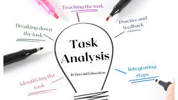

Analyze data from Fitbit users smart devices to gain insight and recommendations. Select one Bellabeat product to apply insights for potential growth opportunities. Primary stakeholders:Urška Sršen and Sando Mur Secondary stakeholders:Bellabeat analytics team

### **Phase 2: Prepare**

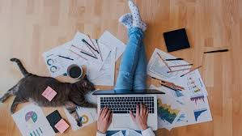

Data was sourced from public dataset that explores smart device users’ daily activities:FitBit Fitness Tracker Data (CC0: Public Domain, dataset made available through Mobius)/ https://www.kaggle.com/arashnic/fitbit The data set has 18 CSV files. Dataset was sourced from consenting 30 FitBit users and generated from a distributed survey via Amazon Mechanical Turk, down to minute-level output for physical activity, heart rate and sleep monitoring.

**Notes about the data** I would be making use of the most relevant data-“Daily_activities”, “Weight”, and “Sleep_daily”. This would give useful insight for marketing team.

**Dataset limitations (ROCCC)**

**Issues with dataset**

- 33 unique user id’s from daily activity dataset, 24 from sleep and 8 from weight
- Some of the data was recorded for only 2 days in the month
- Deleted “Fat” column because only 2 entries were made and remaining cells were blank

###### **Its noteworthy to state that all insights/conclusions deduced from this analysis should be taken with a pinch of salt as data integrity is not 100%**

**Setting up environment** **Notes** setting up R environment by installing and loading the necessary packages(install packages in console environment first to avoid error message)

```r
library(dplyr)
library(tidyr)
library(lubridate)
library(readr)
library(tidyverse)
```

```r
library(ggplot2)
library(here)
library(skimr)
library(janitor)
library(png)
library(jpeg)
library(magick)
```

###### **Library() conflicts can occur when functions in 2 different packages have the same name. In such cases, function from the most recently loaded package would be used by Rstudio**

### Import relevant dataset already renamed using excel

```r
library(readr)
compiled_daily_activity <- read.csv("Daily_activities_merged_New.csv")
weight_log <- read.csv("Weight_log_infoNew.csv")
sleep_daily <- read.csv("Sleep_day_New.csv")
```

### **Phase 3: Process**

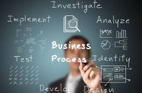

```r
head(compiled_daily_activity)
```

```
##           Id ActivityDate TotalSteps TotalDistance TrackerDistance
## 1 6117666160   2016-04-21      19542         15.01           15.01
## 2 5577150313   2016-04-17      12231          9.14            9.14
## 3 8877689391   2016-04-16      29326         25.29           25.29
## 4 5577150313   2016-05-01      13368          9.99            9.99
## 5 5577150313   2016-04-30      12363          9.24            9.24
## 6 8877689391   2016-04-30      27745         26.72           26.72
##   LoggedActivitiesDistance VeryActiveDistance ModeratelyActiveDistance
## 1                        0               0.98                     0.40
## 2                        0               5.98                     0.83
## 3                        0              13.24                     1.21
## 4                        0               5.31                     1.44
## 5                        0               5.83                     0.79
## 6                        0              21.66                     0.08
##   LightActiveDistance SedentaryActiveDistance VeryActiveMinutes
## 1                5.62                       0                11
## 2                2.32                       0               200
## 3               10.71                       0                94
## 4                3.24                       0               194
## 5                2.61                       0               207
## 6                4.93                       0               124
##   FairlyActiveMinutes LightlyActiveMinutes SedentaryMinutes Calories
## 1                  19                  294              579     4900
## 2                  37                  159              525     4552
## 3                  29                  429              888     4547
## 4                  72                  178              499     4546
## 5                  45                  163              621     4501
## 6                   4                  223             1089     4398
```

```r
head(weight_log)
```

```
##           Id             Date WeightKg WeightPounds   BMI IsManualReport
## 1 1503960366 2016-05-02 23:59     52.6       115.96 22.65           TRUE
## 2 1503960366 2016-05-03 23:59     52.6       115.96 22.65           TRUE
## 3 1927972279  2016-04-13 1:08    133.5       294.32 47.54          FALSE
## 4 2873212765 2016-04-21 23:59     56.7       125.00 21.45           TRUE
## 5 2873212765 2016-05-12 23:59     57.3       126.32 21.69           TRUE
## 6 4319703577 2016-04-17 23:59     72.4       159.61 27.45           TRUE
##         LogId
## 1 1.46223e+12
## 2 1.46232e+12
## 3 1.46051e+12
## 4 1.46128e+12
## 5 1.46310e+12
## 6 1.46094e+12
```

**‘Fat’ row already deleted in excel due to blank cells so not relevant**

```r
head(sleep_daily)
```

```
##           Id        SleepDay TotalSleepRecords TotalMinutesAsleep
## 1 1503960366 2016-04-12 0:00                 1                327
## 2 1503960366 2016-04-13 0:00                 2                384
## 3 1503960366 2016-04-15 0:00                 1                412
## 4 1503960366 2016-04-16 0:00                 2                340
## 5 1503960366 2016-04-17 0:00                 1                700
## 6 1503960366 2016-04-19 0:00                 1                304
##   TotalTimeInBed
## 1            346
## 2            407
## 3            442
## 4            367
## 5            712
## 6            320
```

```r
library(tibble)
tibble(compiled_daily_activity)
```

```
## # A tibble: 940 × 15
##            Id ActivityDate TotalSteps TotalDistance TrackerDistance
##         <dbl> <chr>             <int>         <dbl>           <dbl>
##  1 6117666160 2016-04-21        19542         15.0            15.0
##  2 5577150313 2016-04-17        12231          9.14            9.14
##  3 8877689391 2016-04-16        29326         25.3            25.3
##  4 5577150313 2016-05-01        13368          9.99            9.99
##  5 5577150313 2016-04-30        12363          9.24            9.24
##  6 8877689391 2016-04-30        27745         26.7            26.7
##  7 5577150313 2016-04-24        15764         11.8            11.8
##  8 5577150313 2016-04-16        14269         10.7            10.7
##  9 8378563200 2016-04-21        15148         12.0            12.0
## 10 8378563200 2016-04-14        13318         10.6            10.6
## # ℹ 930 more rows
## # ℹ 10 more variables: LoggedActivitiesDistance <int>,
## #   VeryActiveDistance <dbl>, ModeratelyActiveDistance <dbl>,
## #   LightActiveDistance <dbl>, SedentaryActiveDistance <dbl>,
## #   VeryActiveMinutes <int>, FairlyActiveMinutes <int>,
## #   LightlyActiveMinutes <int>, SedentaryMinutes <int>, Calories <int>
```

Although we have only about one month data worth, I still have to remove those that did not record their daily total steps as this would cause inconsistency in the data analysis. Some also recorded low number of steps and low caloric burn but this could be due to various reasons, therefore we would not be deleting those.

```r
daily_activity_new <- compiled_daily_activity %>%
  filter(TotalSteps !=0)

View(daily_activity_new)
```

```r
tibble(weight_log)
```

```
## # A tibble: 67 × 7
##            Id Date            WeightKg WeightPounds   BMI IsManualReport   LogId
##         <dbl> <chr>              <dbl>        <dbl> <dbl> <lgl>            <dbl>
##  1 1503960366 2016-05-02 23:…     52.6         116.  22.6 TRUE           1.46e12
##  2 1503960366 2016-05-03 23:…     52.6         116.  22.6 TRUE           1.46e12
##  3 1927972279 2016-04-13 1:08    134.          294.  47.5 FALSE          1.46e12
##  4 2873212765 2016-04-21 23:…     56.7         125   21.5 TRUE           1.46e12
##  5 2873212765 2016-05-12 23:…     57.3         126.  21.7 TRUE           1.46e12
##  6 4319703577 2016-04-17 23:…     72.4         160.  27.5 TRUE           1.46e12
##  7 4319703577 2016-05-04 23:…     72.3         159.  27.4 TRUE           1.46e12
##  8 4558609924 2016-04-18 23:…     69.7         154.  27.2 TRUE           1.46e12
##  9 4558609924 2016-04-25 23:…     70.3         155.  27.5 TRUE           1.46e12
## 10 4558609924 2016-05-01 23:…     69.9         154.  27.3 TRUE           1.46e12
## # ℹ 57 more rows
```

I separated the date column for both weight_log and sleep_day into 2 for readability purposes

```r
weight_log_new <- weight_log %>%
  separate(Date, c("Date", "Time"), " ")

View(weight_log_new)
```

```r
tibble(sleep_daily)
```

```
## # A tibble: 413 × 5
##            Id SleepDay       TotalSleepRecords TotalMinutesAsleep TotalTimeInBed
##         <dbl> <chr>                      <int>              <int>          <int>
##  1 1503960366 2016-04-12 0:…                 1                327            346
##  2 1503960366 2016-04-13 0:…                 2                384            407
##  3 1503960366 2016-04-15 0:…                 1                412            442
##  4 1503960366 2016-04-16 0:…                 2                340            367
##  5 1503960366 2016-04-17 0:…                 1                700            712
##  6 1503960366 2016-04-19 0:…                 1                304            320
##  7 1503960366 2016-04-20 0:…                 1                360            377
##  8 1503960366 2016-04-21 0:…                 1                325            364
##  9 1503960366 2016-04-23 0:…                 1                361            384
## 10 1503960366 2016-04-24 0:…                 1                430            449
## # ℹ 403 more rows
```

```r
sleep_daily_new <- sleep_daily %>%
  separate(SleepDay, c("Date", "Time"), " ")

View(sleep_daily_new)
```

```r
colnames(daily_activity_new)
```

```
##  [1] "Id"                       "ActivityDate"
##  [3] "TotalSteps"               "TotalDistance"
##  [5] "TrackerDistance"          "LoggedActivitiesDistance"
##  [7] "VeryActiveDistance"       "ModeratelyActiveDistance"
##  [9] "LightActiveDistance"      "SedentaryActiveDistance"
## [11] "VeryActiveMinutes"        "FairlyActiveMinutes"
## [13] "LightlyActiveMinutes"     "SedentaryMinutes"
## [15] "Calories"
```

```r
colnames(weight_log_new)
```

```
## [1] "Id"             "Date"           "Time"           "WeightKg"
## [5] "WeightPounds"   "BMI"            "IsManualReport" "LogId"
```

```r
colnames(sleep_daily_new)
```

```
## [1] "Id"                 "Date"               "Time"
## [4] "TotalSleepRecords"  "TotalMinutesAsleep" "TotalTimeInBed"
```

Reviewing this data shows that out of 33 contrary to 30 from case citation, only 8 unique ids’ imputed their weight, 24 recorded sleep data, showing incomplete and inconsistent data set. I’ll check for and remove duplicate rows to make data cleaner.

```r
nrow(unique(daily_activity_new))
```

```
## [1] 863
```

```r
nrow(unique(weight_log_new))
```

```
## [1] 67
```

```r
nrow(unique(sleep_daily_new))
```

```
## [1] 410
```

I’ll create new sleep table with unique values

```r
sleep_daily_v2 <- unique(sleep_daily_new)
```

### **Phase 4: Analyse**

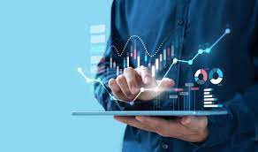

To identify trend and relationships that can help answer business question

```r
skim_without_charts(daily_activity_new)
```

Data summary

| Name | daily_activity_new |
| --- | --- |
| Number of rows | 863 |
| Number of columns | 15 |
| _______________________ |  |
| Column type frequency: |  |
| character | 1 |
| numeric | 14 |
| ________________________ |  |
| Group variables | None |

**Variable type: character**

| skim_variable | n_missing | complete_rate | min | max | empty | n_unique | whitespace |
| --- | --- | --- | --- | --- | --- | --- | --- |
| ActivityDate | 0 | 1 | 10 | 10 | 0 | 31 | 0 |

**Variable type: numeric**

| skim_variable | n_missing | complete_rate | mean | sd | p0 | p25 | p50 | p75 | p100 |
| --- | --- | --- | --- | --- | --- | --- | --- | --- | --- |
| Id | 0 | 1 | 4.857542e+09 | 2.418405e+09 | 1503960366 | 2.320127e+09 | 4.445115e+09 | 6.962181e+09 | 8.877689e+09 |
| TotalSteps | 0 | 1 | 8.319390e+03 | 4.744970e+03 | 4 | 4.923000e+03 | 8.053000e+03 | 1.109250e+04 | 3.601900e+04 |
| TotalDistance | 0 | 1 | 5.980000e+00 | 3.720000e+00 | 0 | 3.370000e+00 | 5.590000e+00 | 7.900000e+00 | 2.803000e+01 |
| TrackerDistance | 0 | 1 | 5.960000e+00 | 3.700000e+00 | 0 | 3.370000e+00 | 5.590000e+00 | 7.880000e+00 | 2.803000e+01 |
| LoggedActivitiesDistance | 0 | 1 | 1.200000e-01 | 6.400000e-01 | 0 | 0.000000e+00 | 0.000000e+00 | 0.000000e+00 | 5.000000e+00 |
| VeryActiveDistance | 0 | 1 | 1.640000e+00 | 2.740000e+00 | 0 | 0.000000e+00 | 4.100000e-01 | 2.280000e+00 | 2.192000e+01 |
| ModeratelyActiveDistance | 0 | 1 | 6.200000e-01 | 9.100000e-01 | 0 | 0.000000e+00 | 3.100000e-01 | 8.600000e-01 | 6.480000e+00 |
| LightActiveDistance | 0 | 1 | 3.640000e+00 | 1.860000e+00 | 0 | 2.340000e+00 | 3.580000e+00 | 4.890000e+00 | 1.071000e+01 |
| SedentaryActiveDistance | 0 | 1 | 0.000000e+00 | 1.000000e-02 | 0 | 0.000000e+00 | 0.000000e+00 | 0.000000e+00 | 1.100000e-01 |
| VeryActiveMinutes | 0 | 1 | 2.302000e+01 | 3.365000e+01 | 0 | 0.000000e+00 | 7.000000e+00 | 3.500000e+01 | 2.100000e+02 |
| FairlyActiveMinutes | 0 | 1 | 1.478000e+01 | 2.043000e+01 | 0 | 0.000000e+00 | 8.000000e+00 | 2.100000e+01 | 1.430000e+02 |
| LightlyActiveMinutes | 0 | 1 | 2.100200e+02 | 9.678000e+01 | 0 | 1.465000e+02 | 2.080000e+02 | 2.720000e+02 | 5.180000e+02 |
| SedentaryMinutes | 0 | 1 | 9.557500e+02 | 2.802900e+02 | 0 | 7.215000e+02 | 1.021000e+03 | 1.189000e+03 | 1.440000e+03 |
| Calories | 0 | 1 | 2.361300e+03 | 7.027100e+02 | 52 | 1.855500e+03 | 2.220000e+03 | 2.832000e+03 | 4.900000e+03 |

```r
skim_without_charts(weight_log_new)
```

Data summary

| Name | weight_log_new |
| --- | --- |
| Number of rows | 67 |
| Number of columns | 8 |
| _______________________ |  |
| Column type frequency: |  |
| character | 2 |
| logical | 1 |
| numeric | 5 |
| ________________________ |  |
| Group variables | None |

**Variable type: character**

| skim_variable | n_missing | complete_rate | min | max | empty | n_unique | whitespace |
| --- | --- | --- | --- | --- | --- | --- | --- |
| Date | 0 | 1 | 10 | 10 | 0 | 31 | 0 |
| Time | 0 | 1 | 4 | 5 | 0 | 20 | 0 |

**Variable type: logical**

| skim_variable | n_missing | complete_rate | mean | count |
| --- | --- | --- | --- | --- |
| IsManualReport | 0 | 1 | 0.61 | TRU: 41, FAL: 26 |

**Variable type: numeric**

| skim_variable | n_missing | complete_rate | mean | sd | p0 | p25 | p50 | p75 | p100 |
| --- | --- | --- | --- | --- | --- | --- | --- | --- | --- |
| Id | 0 | 1 | 7.009282e+09 | 1.950322e+09 | 1.50396e+09 | 6.962181e+09 | 6.962181e+09 | 8.877689e+09 | 8.877689e+09 |
| WeightKg | 0 | 1 | 7.204000e+01 | 1.392000e+01 | 5.26000e+01 | 6.140000e+01 | 6.250000e+01 | 8.505000e+01 | 1.335000e+02 |
| WeightPounds | 0 | 1 | 1.588100e+02 | 3.070000e+01 | 1.15960e+02 | 1.353600e+02 | 1.377900e+02 | 1.875000e+02 | 2.943200e+02 |
| BMI | 0 | 1 | 2.519000e+01 | 3.070000e+00 | 2.14500e+01 | 2.396000e+01 | 2.439000e+01 | 2.556000e+01 | 4.754000e+01 |
| LogId | 0 | 1 | 1.461771e+12 | 7.835136e+08 | 1.46044e+12 | 1.461080e+12 | 1.461800e+12 | 1.462375e+12 | 1.463100e+12 |

```r
skim_without_charts(sleep_daily_v2)
```

Data summary

| Name | sleep_daily_v2 |
| --- | --- |
| Number of rows | 410 |
| Number of columns | 6 |
| _______________________ |  |
| Column type frequency: |  |
| character | 2 |
| numeric | 4 |
| ________________________ |  |
| Group variables | None |

**Variable type: character**

| skim_variable | n_missing | complete_rate | min | max | empty | n_unique | whitespace |
| --- | --- | --- | --- | --- | --- | --- | --- |
| Date | 0 | 1 | 10 | 10 | 0 | 31 | 0 |
| Time | 0 | 1 | 4 | 4 | 0 | 1 | 0 |

**Variable type: numeric**

| skim_variable | n_missing | complete_rate | mean | sd | p0 | p25 | p50 | p75 | p100 |
| --- | --- | --- | --- | --- | --- | --- | --- | --- | --- |
| Id | 0 | 1 | 4.994963e+09 | 2.060863e+09 | 1503960366 | 3.977334e+09 | 4702921684.0 | 6962181067 | 8792009665 |
| TotalSleepRecords | 0 | 1 | 1.120000e+00 | 3.500000e-01 | 1 | 1.000000e+00 | 1.0 | 1 | 3 |
| TotalMinutesAsleep | 0 | 1 | 4.191700e+02 | 1.186400e+02 | 58 | 3.610000e+02 | 432.5 | 490 | 796 |
| TotalTimeInBed | 0 | 1 | 4.584800e+02 | 1.274600e+02 | 61 | 4.037500e+02 | 463.0 | 526 | 961 |

Lets compare Skims() with summary() function

```r
summary(daily_activity_new)
```

```
##        Id            ActivityDate         TotalSteps    TotalDistance
##  Min.   :1.504e+09   Length:863         Min.   :    4   Min.   : 0.00
##  1st Qu.:2.320e+09   Class :character   1st Qu.: 4923   1st Qu.: 3.37
##  Median :4.445e+09   Mode  :character   Median : 8053   Median : 5.59
##  Mean   :4.858e+09                      Mean   : 8319   Mean   : 5.98
##  3rd Qu.:6.962e+09                      3rd Qu.:11092   3rd Qu.: 7.90
##  Max.   :8.878e+09                      Max.   :36019   Max.   :28.03
##  TrackerDistance  LoggedActivitiesDistance VeryActiveDistance
##  Min.   : 0.000   Min.   :0.0000           Min.   : 0.000
##  1st Qu.: 3.370   1st Qu.:0.0000           1st Qu.: 0.000
##  Median : 5.590   Median :0.0000           Median : 0.410
##  Mean   : 5.964   Mean   :0.1159           Mean   : 1.637
##  3rd Qu.: 7.880   3rd Qu.:0.0000           3rd Qu.: 2.275
##  Max.   :28.030   Max.   :5.0000           Max.   :21.920
##  ModeratelyActiveDistance LightActiveDistance SedentaryActiveDistance
##  Min.   :0.0000           Min.   : 0.000      Min.   :0.00000
##  1st Qu.:0.0000           1st Qu.: 2.345      1st Qu.:0.00000
##  Median :0.3100           Median : 3.580      Median :0.00000
##  Mean   :0.6182           Mean   : 3.639      Mean   :0.00175
##  3rd Qu.:0.8650           3rd Qu.: 4.895      3rd Qu.:0.00000
##  Max.   :6.4800           Max.   :10.710      Max.   :0.11000
##  VeryActiveMinutes FairlyActiveMinutes LightlyActiveMinutes SedentaryMinutes
##  Min.   :  0.00    Min.   :  0.00      Min.   :  0.0        Min.   :   0.0
##  1st Qu.:  0.00    1st Qu.:  0.00      1st Qu.:146.5        1st Qu.: 721.5
##  Median :  7.00    Median :  8.00      Median :208.0        Median :1021.0
##  Mean   : 23.02    Mean   : 14.78      Mean   :210.0        Mean   : 955.8
##  3rd Qu.: 35.00    3rd Qu.: 21.00      3rd Qu.:272.0        3rd Qu.:1189.0
##  Max.   :210.00    Max.   :143.00      Max.   :518.0        Max.   :1440.0
##     Calories
##  Min.   :  52
##  1st Qu.:1856
##  Median :2220
##  Mean   :2361
##  3rd Qu.:2832
##  Max.   :4900
```

```r
summary(weight_log_new)
```

```
##        Id                Date               Time              WeightKg
##  Min.   :1.504e+09   Length:67          Length:67          Min.   : 52.60
##  1st Qu.:6.962e+09   Class :character   Class :character   1st Qu.: 61.40
##  Median :6.962e+09   Mode  :character   Mode  :character   Median : 62.50
##  Mean   :7.009e+09                                         Mean   : 72.04
##  3rd Qu.:8.878e+09                                         3rd Qu.: 85.05
##  Max.   :8.878e+09                                         Max.   :133.50
##   WeightPounds        BMI        IsManualReport      LogId
##  Min.   :116.0   Min.   :21.45   Mode :logical   Min.   :1.460e+12
##  1st Qu.:135.4   1st Qu.:23.96   FALSE:26        1st Qu.:1.461e+12
##  Median :137.8   Median :24.39   TRUE :41        Median :1.462e+12
##  Mean   :158.8   Mean   :25.19                   Mean   :1.462e+12
##  3rd Qu.:187.5   3rd Qu.:25.56                   3rd Qu.:1.462e+12
##  Max.   :294.3   Max.   :47.54                   Max.   :1.463e+12
```

```r
summary(sleep_daily_v2)
```

```
##        Id                Date               Time           TotalSleepRecords
##  Min.   :1.504e+09   Length:410         Length:410         Min.   :1.00
##  1st Qu.:3.977e+09   Class :character   Class :character   1st Qu.:1.00
##  Median :4.703e+09   Mode  :character   Mode  :character   Median :1.00
##  Mean   :4.995e+09                                         Mean   :1.12
##  3rd Qu.:6.962e+09                                         3rd Qu.:1.00
##  Max.   :8.792e+09                                         Max.   :3.00
##  TotalMinutesAsleep TotalTimeInBed
##  Min.   : 58.0      Min.   : 61.0
##  1st Qu.:361.0      1st Qu.:403.8
##  Median :432.5      Median :463.0
##  Mean   :419.2      Mean   :458.5
##  3rd Qu.:490.0      3rd Qu.:526.0
##  Max.   :796.0      Max.   :961.0
```

```r
daily_activity_wd2 <- daily_activity_new
  daily_activity_wd2$day <- strftime(daily_activity_wd2$ActivityDate, "%A")

View(daily_activity_wd2)
```

```r
sleep_daily_wd <- sleep_daily_v2
  sleep_daily_wd$day <- strftime(sleep_daily_wd$Date, "%A")

View(sleep_daily_wd)
```

**Summary** This overview shows that cleaning was done properly and all issues have been corrected.

I’ll merge the tables using only columns i want

```r
merge_table1 <- merge(daily_activity_wd2, weight_log_new, by.x = "Id",
                      by.y = "Id", all.x=TRUE, all.y = TRUE)

View(merge_table1)
```

```r
merge_table2 <- merge(merge_table1, sleep_daily_wd, by.x = "Id",
                      by.y = "Id", all.x = TRUE, all.y = TRUE)

View(merge_table2)
```

```r
merge_all_tables <- merge_table2 %>% select(-one_of('TrackerDistance','LoggedActivitiesDistance', 'VeryActiveDistance', 'ModeratelyActiveDistance', 'LightActiveDistance', 'SedentaryActiveDistance', 'WeightPounds', 'IsManualReport', 'LogId', 'TotalSleepRecords'))
```

```r
summary(merge_all_tables)
```

```
##        Id            ActivityDate         TotalSteps    TotalDistance
##  Min.   :1.504e+09   Length:42745       Min.   :    4   Min.   : 0.000
##  1st Qu.:6.118e+09   Class :character   1st Qu.: 5908   1st Qu.: 3.910
##  Median :6.962e+09   Mode  :character   Median :10199   Median : 6.820
##  Mean   :6.262e+09                      Mean   : 9514   Mean   : 6.512
##  3rd Qu.:6.962e+09                      3rd Qu.:12109   3rd Qu.: 8.350
##  Max.   :8.878e+09                      Max.   :36019   Max.   :28.030
##
##  VeryActiveMinutes FairlyActiveMinutes LightlyActiveMinutes SedentaryMinutes
##  Min.   :  0.00    Min.   :  0.00      Min.   :  0.0        Min.   :   0.0
##  1st Qu.:  0.00    1st Qu.:  3.00      1st Qu.:195.0        1st Qu.: 637.0
##  Median : 15.00    Median : 14.00      Median :238.0        Median : 697.0
##  Mean   : 23.93    Mean   : 18.09      Mean   :235.7        Mean   : 712.4
##  3rd Qu.: 38.00    3rd Qu.: 32.00      3rd Qu.:288.0        3rd Qu.: 745.0
##  Max.   :210.00    Max.   :143.00      Max.   :518.0        Max.   :1440.0
##
##     Calories       day.x              Date.x             Time.x
##  Min.   :  52   Length:42745       Length:42745       Length:42745
##  1st Qu.:1850   Class :character   Class :character   Class :character
##  Median :2046   Mode  :character   Mode  :character   Mode  :character
##  Mean   :2111
##  3rd Qu.:2194
##  Max.   :4900
##
##     WeightKg           BMI           Date.y             Time.y
##  Min.   : 52.60   Min.   :21.45   Length:42745       Length:42745
##  1st Qu.: 61.20   1st Qu.:23.89   Class :character   Class :character
##  Median : 61.50   Median :24.00   Mode  :character   Mode  :character
##  Mean   : 63.15   Mean   :24.37
##  3rd Qu.: 62.00   3rd Qu.:24.21
##  Max.   :133.50   Max.   :47.54
##  NA's   :8409     NA's   :8409
##  TotalMinutesAsleep TotalTimeInBed     day.y
##  Min.   : 58        Min.   : 61.0   Length:42745
##  1st Qu.:400        1st Qu.:424.0   Class :character
##  Median :442        Median :457.0   Mode  :character
##  Mean   :434        Mean   :458.2
##  3rd Qu.:476        3rd Qu.:510.0
##  Max.   :796        Max.   :961.0
##  NA's   :963        NA's   :963
```

I will now analyze the percentage of active minutes for each categorized column(active, fairly, lightly and sedentary) using a pie chart.

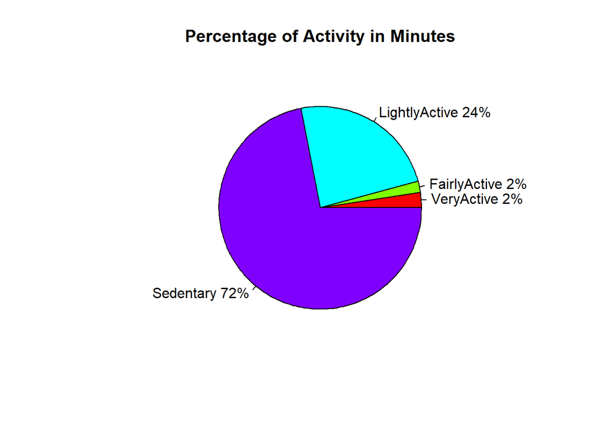

```r
VeryActiveMin <- sum(merge_all_tables$VeryActiveMinutes)
FairlyActiveMin <- sum(merge_all_tables$FairlyActiveMinutes)
LightlyActiveMin <- sum(merge_all_tables$LightlyActiveMinutes)
SedentaryMin <- sum(merge_all_tables$SedentaryMinutes)
TotalMin <- VeryActiveMin + FairlyActiveMin + LightlyActiveMin + SedentaryMin

slices <- c(VeryActiveMin, FairlyActiveMin, LightlyActiveMin, SedentaryMin)
lbls <-c("VeryActive", "FairlyActive", "LightlyActive", "Sedentary")
pct <- round(slices/sum(slices)*100)
lbls <- paste(lbls, pct)
lbls <- paste(lbls, "%", sep ="")
pie(slices, labels = lbls, col = rainbow(length(lbls)), main = "Percentage of Activity in Minutes" )
```

Now, lets see the relationship between total steps taken and calories burned.

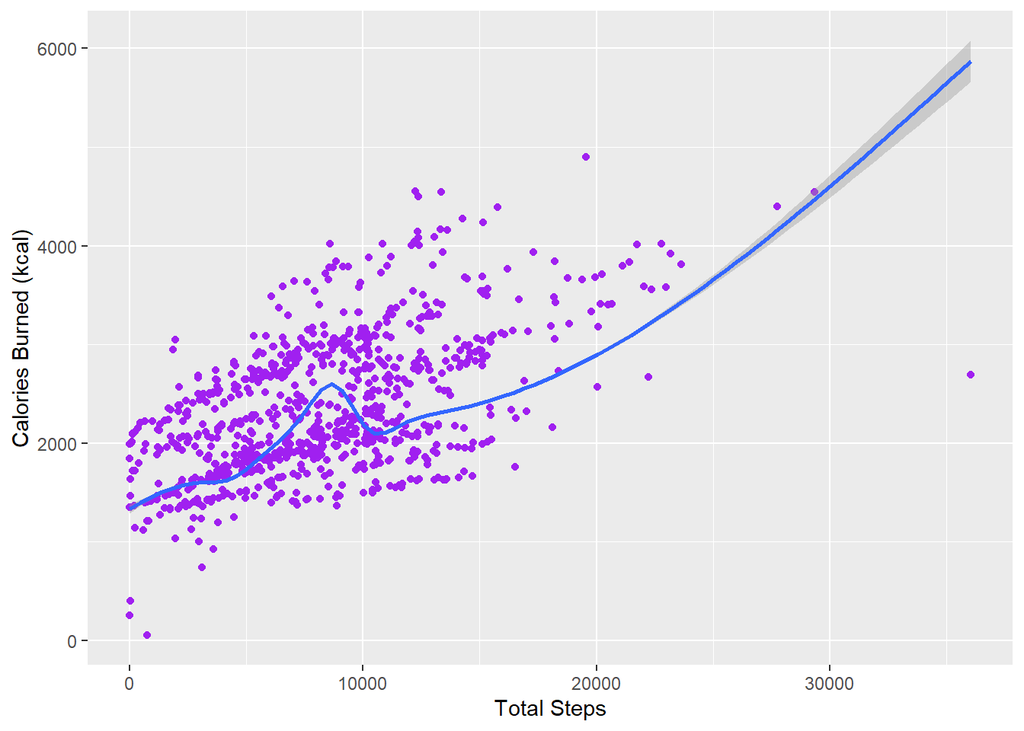

```r
ggplot(data = merge_all_tables)+
  geom_point(mapping = aes(x=TotalSteps, y=Calories), color= "purple")+
  geom_smooth(mapping = aes(x=TotalSteps, y=Calories))+
  labs(tittle = "Relationship Between Total Steps and Calories Burned", x="Total Steps", y= "Calories Burned (kcal)")
```

This plot shows a positive relationship between the number of steps an individual taken and calorie burning, the more steps a person takes i.e increased activity equals higher calorie burn. This statement is proven true by the plot below detailing only active minutes against calorie burn.

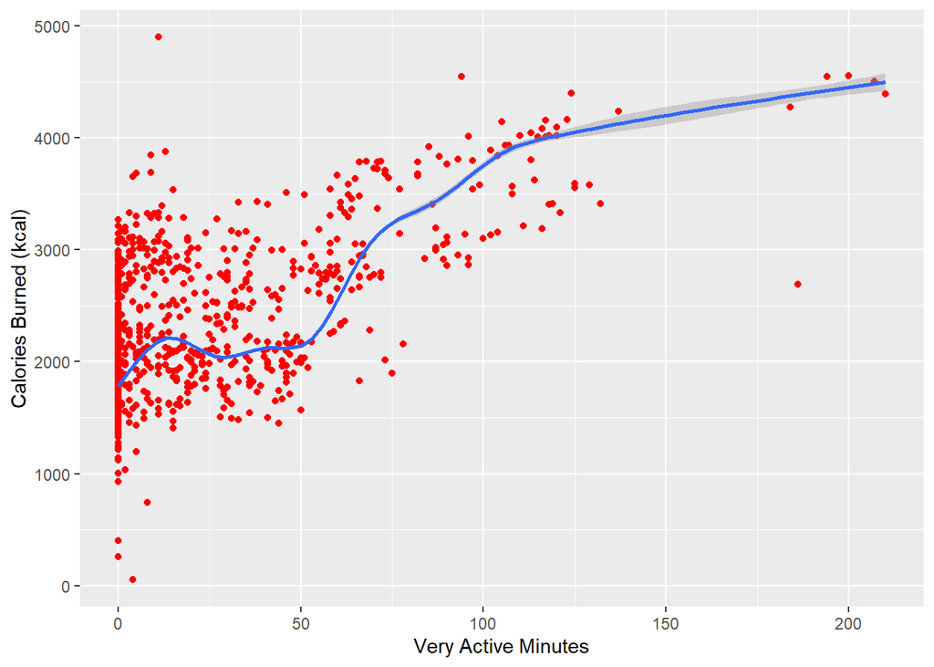

```r
ggplot(data = merge_all_tables)+
  geom_point(mapping = aes(x=VeryActiveMinutes, y=Calories), color= "red")+
  geom_smooth(mapping = aes(x=VeryActiveMinutes, y=Calories))+
  labs(tittle = "Relationship Between Very Active Minutes and Calories Burned", x="Very Active Minutes", y="Calories Burned (kcal)")
```

I want to view how user activity is on each day of the week

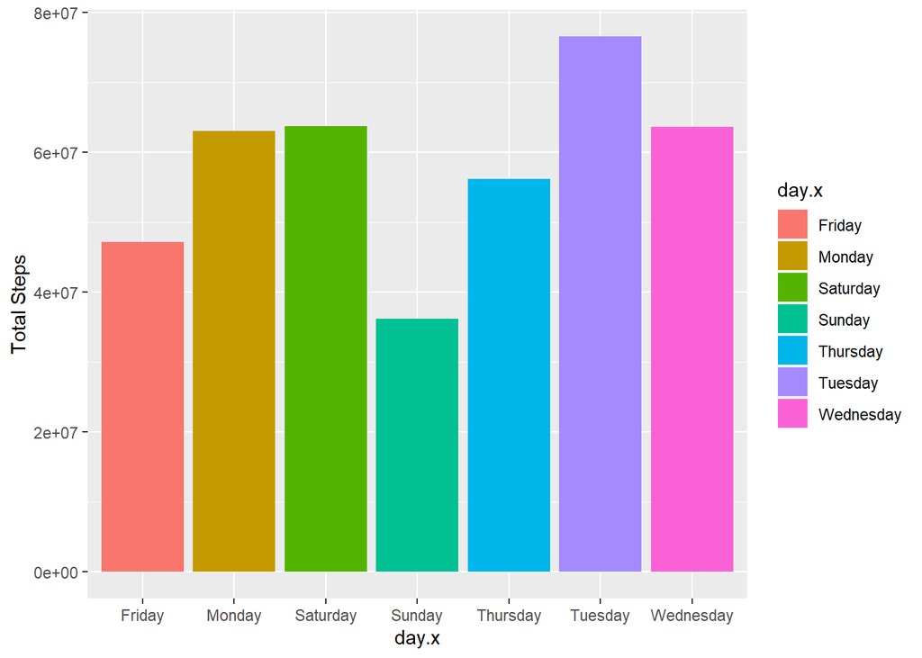

```r
ggplot(data=merge_all_tables, aes(x=day.x, y=TotalSteps, fill=day.x))+
  geom_bar(stat = "identity")+
  ylab("Total Steps")
```

Saturday and Wednesday show similar activity level while Tuesday has the most steps recorded

### **Phase 5:Share**

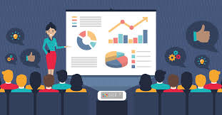

**Summary of key findings:** User’s average daily step count is 8319. This is low compared to the CDC recommended step count of 10,000.

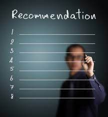

**Recommendations** Recommendations

To attain users to aspire to attain the CDC recommendation of 10,000 steps per day, our app should have preset milestones for users every 2000 steps with a notification alerting them of how many more steps they need to reach 10,000 or the app can allow users set an achievable number of steps for each quadrant of the day i.e separate 24 hours into 4 quadrants of 6 hours each.

Pop ups on the app that show link to sites were users can get health and exercise tips

Our app should be designed to trigger device to alert users when they have been sedentary for too long, except during scheduled night sleep.

To enforce being active, our app should have a feature that lets users allow for notifications pushed to their phone, as well as their wellness watch device. This can be done every hour to encourage them to be active.

Our app should provide users with the ability to setup a sleep schedule, that can then create notifications for when it is time to sleep.

We should be alerting users to their activity level

Have milestone alerts and badge rewards for users who attain daily or weekly goals in order to boost better participation and morale.

There should be weekly and monthly summary on users activity and also recommendations on how to improve when needed

After one month, we should prompt users to fill out a survey or list one feature they would like added to the app or one of the Bellabeat devices.

Enhance User Experience and App Features: continuously work to improve BellaBeat apps’ user experience. Make regular updates, show insights on a regular basisand survey the customers for suggestions on the app

## **References**

Sandee LaMotte,CNN. (2022, October 10). 10 steps for weight loss and wellness. Retrieved from https://www.cnn.com/2022/10/10/health/steps-for-weight-loss-wellness/index.html Centers for Disease Control and Prevention. (n.d.). Physical Activity - Basics - Adults. Retrieved from https://www.cdc.gov/physicalactivity/basics/adults/index.html Canadian Society for Exercise Physiology. (n.d.). Canadian 24-Hour Movement Guidelines for Adults. Retrieved from https://csepguidelines.ca/ Cleveland Clinic. (n.d.). Calories Burned in a Day. Retrieved from https://health.clevelandclinic.org/calories-burned-in-a-day/ Harvard T.H. Chan School of Public Health. (n.d.). Staying Active. Retrieved from https://www.hsph.harvard.edu/nutritionsource/staying-active/ Cleveland Clinic. (n.d.). Pulse (Heart Rate). Retrieved from https://my.clevelandclinic.org/health/diagnostics/17402-pulse--heart-rate Centers for Disease Control and Prevention. (n.d.). How Much Sleep Do I Need? Retrieved from https://www.cdc.gov/sleep/about_sleep/how_much_sleep.html Medical News Today. (n.d.). What to know about BMI and body fat percentage. Retrieved from https://www.medicalnewstoday.com/articles/323446#body-mass-index-bmi